# CTA1 mRNA and protein induction (Figure 3)

Bin He

2022-10-25 (updated 2023-01-27)

```r
library(tidyverse)
library(ggtext)
#library(mgcv)
library(broom)
library(cowplot)
```

# *CTA1* mRNA induction [Fig. 3A]

Experiment was performed on 2020/03/25-27, see [here](https://docs.google.com/spreadsheets/d/1dClNE3oDJyQQlZwcf_NoHs56Wi1G938K44yyCrwCpCQ/edit?usp=sharing) for experimental methods. Briefly, *C. glabrata* cells were grown to mid-log phase (OD~0.5), washed and treated with either SC media (mock), 0mM Pi (no Pi) or 10 mM H2O2 for 45 minutes. RNA was extracted and qRT-PCR was performed with *ACT1* used as a reference gene and the mock treated sample as the reference sample. The following dataset was extracted from the above spreadsheet.

```r
rna <- read_tsv("input/CTA1-mRNA-qPCR/20200327-CTA1-mRNA-Ct.txt") %>%
  mutate(Treatment = fct_recode(Treatment,
                                H2O2 = "10mM H2O2",
                                `-Pi` = "no Pi",
                                Mock = "untreated"))
# check the control wells
rna %>% filter(Group %in% c("noRT", "NTC"))
```

| Pos | Group | Name | Target | Treatment | Dilution | Cp |
| --- | --- | --- | --- | --- | --- | --- |
| A10 | noRT | yH001 | ACT1 | NA | 100 | 27.89 |
| A11 | noRT | yH001 | ACT1 | NA | 100 | NA |
| A12 | noRT | yH001 | ACT1 | NA | 100 | 31.81 |
| B10 | NTC | NA | ACT1 | NA | 100 | NA |
| B11 | NTC | NA | ACT1 | NA | 100 | NA |
| B12 | NTC | NA | ACT1 | NA | 100 | NA |
| C10 | noRT | yH001 | CTA1_C | NA | 100 | 12.38 |
| C11 | noRT | yH001 | CTA1_C | NA | 100 | 33.36 |
| C12 | noRT | yH001 | CTA1_C | NA | 100 | NA |
| D10 | NTC | NA | CTA1_C | NA | 100 | NA |

[output cut: 8 more lines]

```r
# get the subset for "unknowns" vs "standards"
rnaT <- rna %>% filter(Group == "unknown")
rnaS <- rna %>% filter(Group == "standard")
```

> C10 and D12 are problematic

Check the standard curve

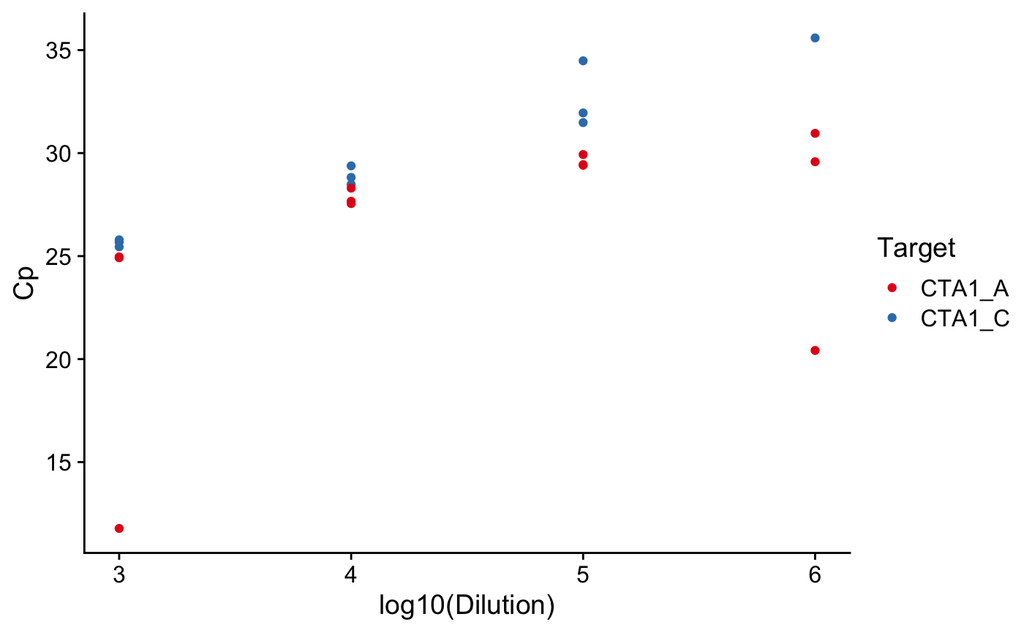

```r
p <- rnaS %>%
  ggplot(aes(x = log10(Dilution), y = Cp)) +
  geom_point(aes(color = Target)) +
  scale_color_brewer(palette = "Set1") +
  theme_cowplot()
p
```

```r
rnaS %>%
  #select(Target, Dilution, Cp) %>%
  mutate(x = log10(Dilution)) %>%
  group_by(Target) %>%
  nest() %>%
  mutate(test = map(data, function(df) lm(Cp ~ x, data = df)),
         slope = map(test, tidy)) %>%
  unnest(slope) %>%
  filter(term == "x") %>%
  select(Target, slope = estimate, std.error, p.value)
```

| Target | slope | std.error | p.value |
| --- | --- | --- | --- |
| CTA1_C | 3.411458 | 0.2776703 | 1.791252e-06 |
| CTA1_A | 2.105667 | 1.3042299 | 1.374951e-01 |

```r
NA
```

> primer set C behaves better than primer set A

Visualize the Ct values for the unknown samples

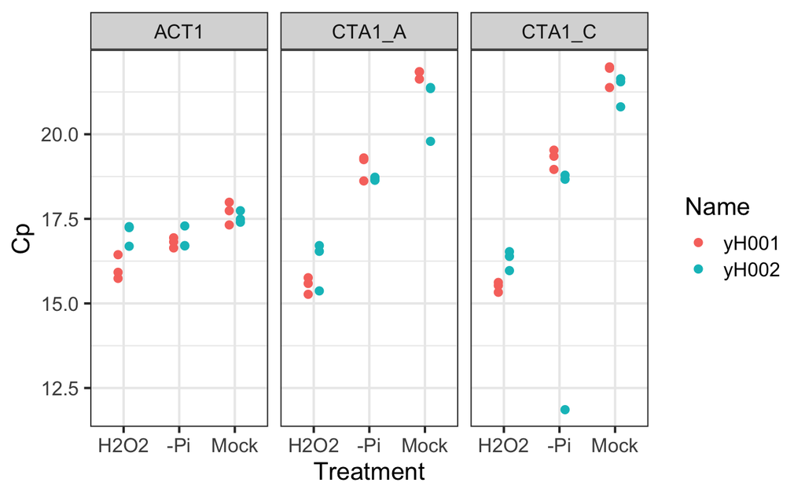

```r
p <- rnaT %>%
  ggplot(aes(x = Treatment, y = Cp)) +
  geom_point(aes(color = Name), shape = 16, size = 2.5, position = position_dodge(width = 0.4)) +
  facet_wrap(~Target) +
  theme_bw(base_size = 16)
p
```

Calculate ∆∆Ct. Because the dilution amount is the same across all samples, we don’t have to make any adjustments. TRUE

```r
rna.dCt <- rnaT %>%
  # calculate mean Ct for the reference gene
  filter(Target == "ACT1") %>%
  group_by(Name, Treatment) %>%
  summarize(refG = mean(Cp), .groups = "drop") %>%
  # append the reference gene Ct mean to the original data
  right_join(filter(rnaT, Target != "ACT1")) %>%
  # subtract the reference gene Ct mean from each target
  mutate(dCt = Cp - refG) %>%
  select(-refG)
rna.ddCt <- rna.dCt %>%
  # calculate mean dCt for the reference sample
  filter(Treatment == "Mock") %>%
  group_by(Name, Target) %>%
  summarize(refT = mean(dCt), .groups = "drop") %>%
  right_join(rna.dCt) %>%
  mutate(ddCt = dCt - refT, FC = 2^-ddCt) %>%
  select(-refT)
```

Visualize fold changes relative to the mock treated sample and normalized by ACT1. Using CTA1 primer set A. Overall pattern is highly consistent. Primer set C data contains one outlier that is most likely due to experimental mistakes – one -Pi sample showed >400 fold induction

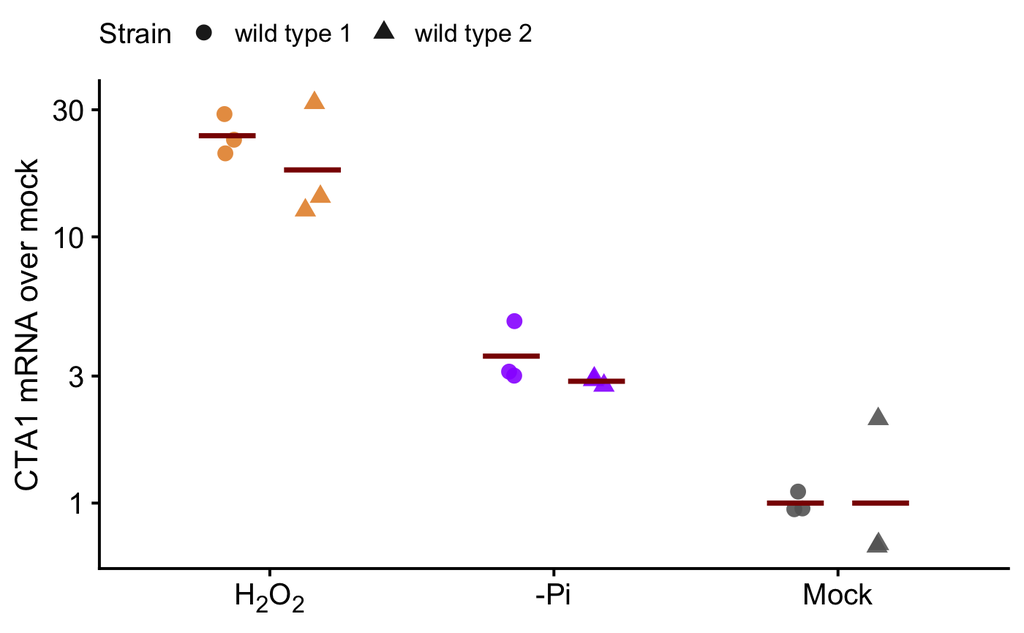

```r
treat_color <- c(`H<sub>2</sub>O<sub>2</sub>` = "#E69138", `-Pi` = "#9900FF", Mock = "#666666")
p.rna <- filter(rna.ddCt, Target == "CTA1_A") %>%
  mutate(Strain = fct_recode(Name, `wild type 1` = "yH001", `wild type 2` = "yH002"),
         Treatment = fct_recode(Treatment, `H<sub>2</sub>O<sub>2</sub>` = "H2O2")) %>%
  ggplot(aes(x = Treatment, y = FC)) +
  geom_point(aes(shape = Strain, color = Treatment), size = 3.5, alpha = 0.9,
             position = position_jitterdodge(dodge.width = 0.6, jitter.width = 0.2)) +
  scale_shape_discrete(solid = TRUE) +
  scale_color_manual(values = treat_color, guide = "none") +
  stat_summary(aes(group = Strain), fun = "mean", geom = "crossbar", color = "darkred",
               position = position_dodge(0.6), width = 0.4) +
  scale_y_log10() + ylab("CTA1 mRNA over mock") +
  theme_cowplot(line_size = 0.7, font_size = 16) +
  theme(legend.text = element_text(size = rel(0.8)),
        legend.title = element_text(size = rel(0.9)),
        legend.position = "top",
        axis.title.x = element_blank(),
        axis.text.x = element_markdown(size = rel(1.1)),
        axis.text.y = element_text(size = rel(1.1)))
p.rna
ggsave("output/20221213-CTA1-mRNA-qRT-PCR.png", width = 4, height = 3.5)
```

Statistical tests

```r
lm <- rna.ddCt %>% filter(Target == "CTA1_A") %>%
  mutate(Treatment = fct_relevel(Treatment, "Mock")) %>%
  rename(Strain = Name) %>%
  lm(ddCt ~ Treatment + Strain, data = .)
summary(lm)
```

```
Call:
lm(formula = ddCt ~ Treatment + Strain, data = .)

Residuals:
    Min      1Q  Median      3Q     Max
-1.1733 -0.0350  0.1083  0.2075  0.5933

Coefficients:
              Estimate Std. Error t value Pr(>|t|)
(Intercept)    -0.1233     0.2293  -0.538    0.599
TreatmentH2O2  -4.3700     0.2808 -15.563 3.12e-10 ***
Treatment-Pi   -1.6767     0.2808  -5.971 3.42e-05 ***
StrainyH002     0.2467     0.2293   1.076    0.300
---
Signif. codes:  0 ‘***’ 0.001 ‘**’ 0.01 ‘*’ 0.05 ‘.’ 0.1 ‘ ’ 1

Residual standard error: 0.4864 on 14 degrees of freedom
Multiple R-squared:  0.9465,    Adjusted R-squared:  0.935
F-statistic: 82.58 on 3 and 14 DF,  p-value: 3.844e-09
```

# Cta1-GFP protein levels [Fig. 3B]

## Prepare data

```r
pi.dat.long <- read_csv("input/wt-Pi-H2O2/Long_data_CTA1-GFP.csv", col_types = cols()) %>%
  mutate(new_time = as.numeric(gsub("min","",Time))) %>%
  arrange(new_time, Treatment)
```

### Bin’s version

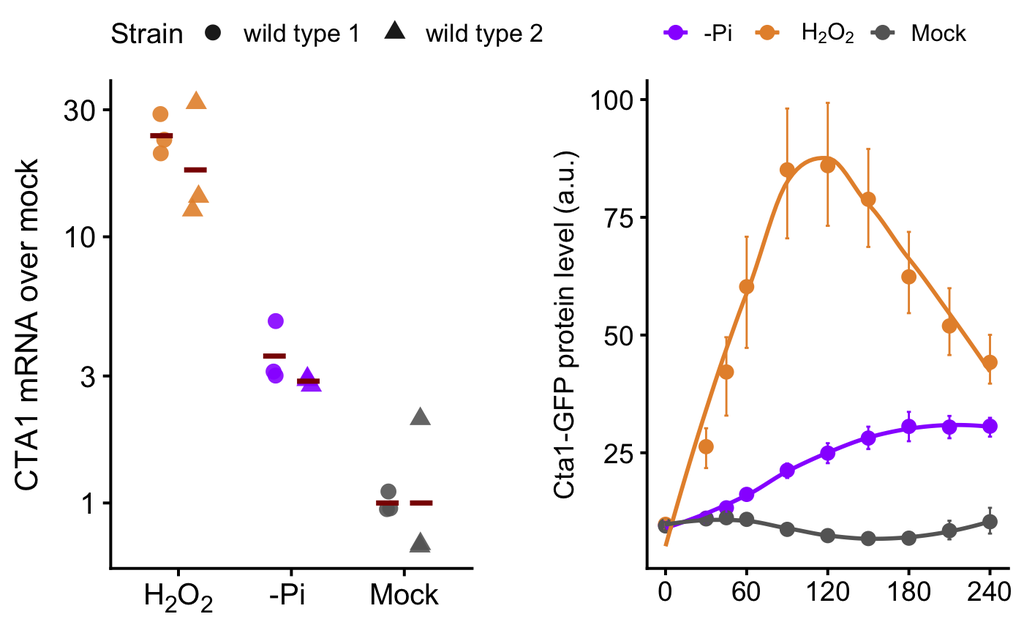

```r
treat_color <- c(`2mM H2O2` = "#E69138", `0mM Pi` = "#9900FF", Control = "#666666")

p.gfp <- pi.dat.long %>%
  filter(!is.na(median)) %>%
  ggplot(aes(x = new_time, y = median, color = Treatment)) +
  p.timecourse +
  scale_color_manual(values= treat_color, labels = c("-Pi", bquote(~H[2]*O[2]), "Mock")) +
  theme(legend.text = element_text(size = rel(0.85), face = 1),
        legend.position="top",
        legend.title = element_blank())
plot_grid(p.rna, NULL, p.gfp, nrow = 1, rel_widths = c(1, 0.1, 1), align = "hv")
#ggsave("output/20221117-Pi-H2O2-timecourse.png", width = 4, height = 3.5)
ggsave("output/20221214-CTA1-rna-gfp-align.png", width = 8, height = 3.5)
```